# How does sampling type effect parameter estimate bias and precision?

## Introduction

The parameters of a von Bertalanffy growth function are commonly estimated given age-length data for individual fish. These parameters are used to assess growth, mortality, and production of a fish population. These parameters are also used to estimate mortality and production.  
* uncertainty (i.e., se is not of concern)

## Objectives

The objectives of this analysis were to compare the effect of simple random  
sampling (srs), binning, age length key expansion, and reweighting on parameter estimates and uncertainty.

The expectation was that parameter estimate bias should not be terrible but the uncertainty around the estimates may be overly precise. In other words, non-random sampling will likely result in over estimation of precision.

## Methods

True population.—A reference true population was generated and simple random sample. We used the same population parameters used by C for two life-history types: short-lived high-productivity (SLHP) and long-lived low-productivity (LLLP) species

$L_{age}=L_{\infty}\cdot e^{-k\cdot(age-t_0)}$

error:  
$e_i \sim N(0,\sigma)$ or  
$e_i \sim e^{N(0,\sigma)}$

Sample size was same as Coogins

Sampling strategies.—  
1. Binning 2. Age length key expansion 3. Rewighting

#### Analysis

## Results

### Reference dataset

### Bias and precision

## Figures

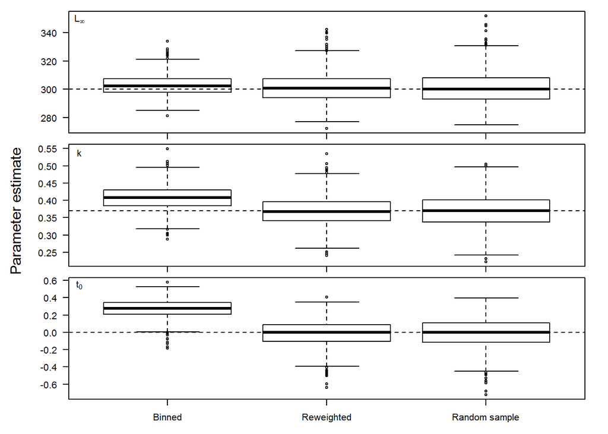

Figure 1. Effect of sampling type and estimation on the distribution of point estimates of Linf, k, and t0 for a short lived, small bodied, fast growing fish. The dotted line denotes the true value.

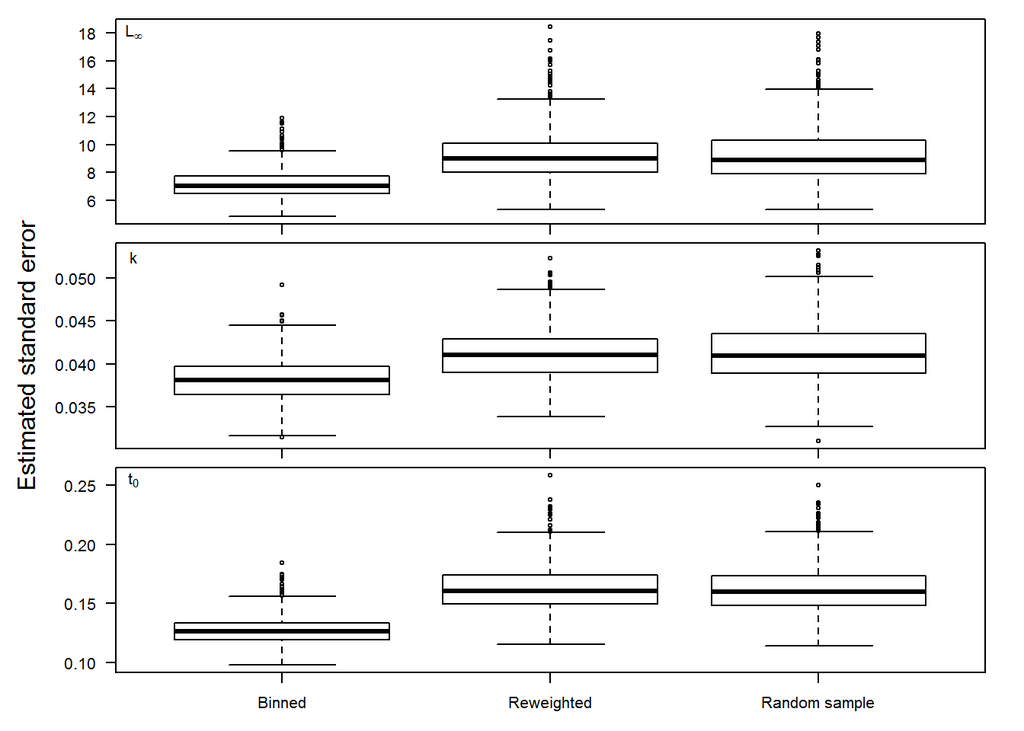

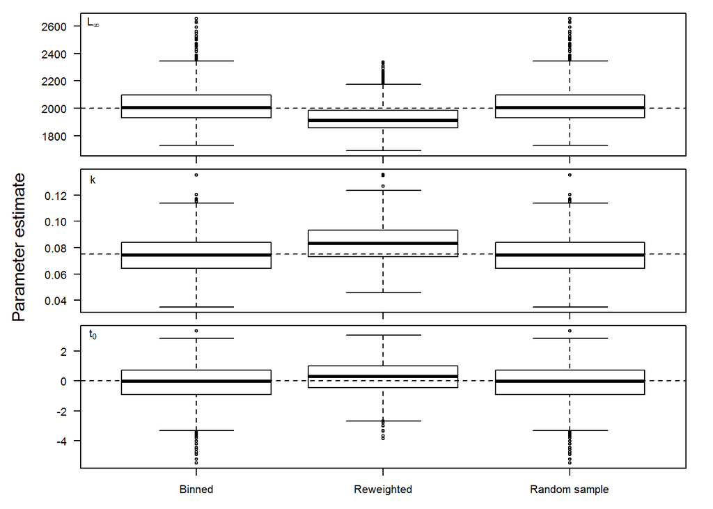

Figure 3. Effect of sampling type and estimation on the distribution of point estimates of Linf, k, and t0 for a long lived, large bodied, slow growing fish. The dotted line denotes the true value.

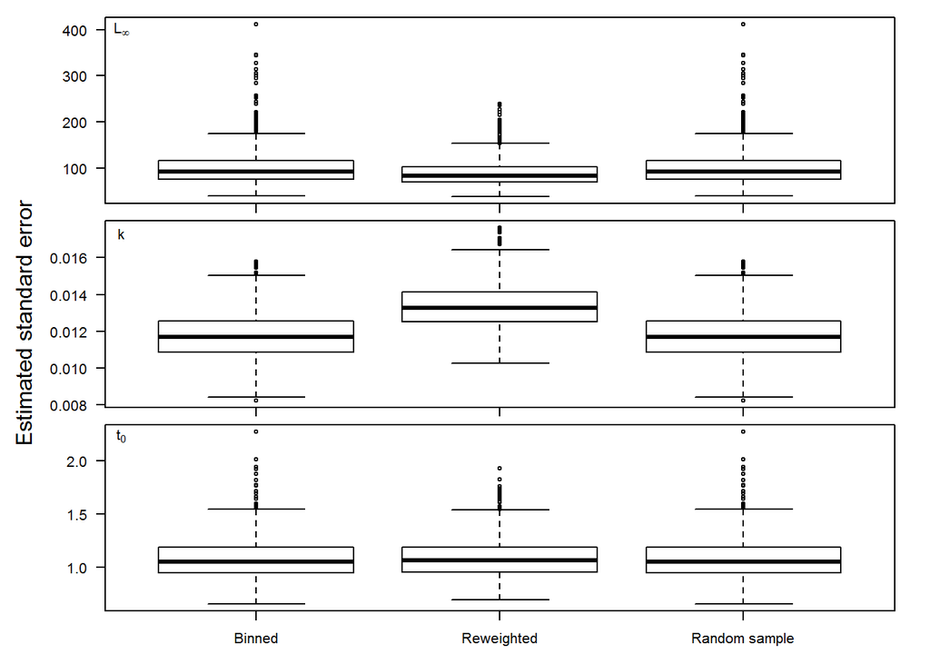

## Tables

| lht | linf | k | t0 |
| --- | --- | --- | --- |
| ssf | 300 | 0.370 | 0 |
| lls | 2000 | 0.075 | 0 |